# Final version - HW4 - mw5599

```python
import pandas as pd
import numpy as np

s = '/Users/morganwaddington/Documents/Tandon/Classes/Machine-Learning/datasets/DataSetForPhishingVSBenignUrl.csv'
df = pd.read_csv(s, encoding='utf-8')
```

```python
from sklearn.preprocessing import LabelEncoder
label_encoder = LabelEncoder()

for col in [31]:
    df.iloc[:, col] = label_encoder.fit_transform(df.iloc[:, col])
```

```python
y = df.iloc[:, 79].values

y = np.where(np.isin(y, ['benign']), 0, 1)

X = df.iloc[:, 0:79].values #41 is correct
```

```python
from sklearn.model_selection import train_test_split
X_train, X_test, y_train, y_test = train_test_split(X, y, test_size=0.2, random_state=1, stratify=y)
```

```python
print('Labels counts in y:', np.bincount(y))
print('Labels counts in y_train:', np.bincount(y_train))
print('Labels counts in y_test:', np.bincount(y_test))
```

```
Labels counts in y: [ 7781 28926]
Labels counts in y_train: [ 6225 23140]
Labels counts in y_test: [1556 5786]
```

```python
from imblearn.under_sampling import RandomUnderSampler
under = RandomUnderSampler(random_state=1)
X_train, y_train = under.fit_resample(X_train, y_train)

print('Labels counts in y_train after undersampling:', np.bincount(y_train))
```

```
Labels counts in y_train after undersampling: [6225 6225]
```

```python
from sklearn.metrics import accuracy_score, confusion_matrix, classification_report
from IPython.display import display, HTML

def print_results(y_test_pred):
    cm = confusion_matrix(y_test, y_test_pred)
    print('Confusion Matrix:')
    print(cm,'\n')


    report = classification_report(y_test, y_test_pred)
    print('Classification Report:')
    print(report)

display(HTML(f"<h2>1. Using the Scikit-Learn Library train the Decision Tree Classifier</h2>"))


from sklearn.tree import DecisionTreeClassifier
tree_model = DecisionTreeClassifier(criterion='gini',
                                    max_depth=1,
                                    random_state=1)
tree_model.fit(X_train, y_train)


display(HTML(f"<h2>Test result for Decision Tree:</h2>"))
y_test_pred = tree_model.predict(X_test)
print_results(y_test_pred)
```

1. Using the Scikit-Learn Library train the Decision Tree Classifier

Test result for Decision Tree:

```
Confusion Matrix:
[[1425  131]
 [1345 4441]]

Classification Report:
              precision    recall  f1-score   support

           0       0.51      0.92      0.66      1556
           1       0.97      0.77      0.86      5786

    accuracy                           0.80      7342
   macro avg       0.74      0.84      0.76      7342
weighted avg       0.87      0.80      0.82      7342
```

An accuracy of 80% is decent for a single-level decision tree. The precision for classifying non-benign (malicious) URLs is high at 97%, however the precision for identifying benign URLs is very low at 51%. The model struggles to correctly classify benign URLs...so adding more levels to the decision tree could improve its ability to differentiate between the classes more accurately.

```python
display(HTML(f"<h1>2. Run the model for trees of depth 1, 2, 3, 4, 5, and 6 and for Gini and Entropy:</h1>"))


display(HTML(f"<h2>Gini - Level 1:</h2>"))
tree_model = DecisionTreeClassifier(criterion='gini', max_depth=1,random_state=1)
tree_model.fit(X_train, y_train)
y_test_pred = tree_model.predict(X_test)
print_results(y_test_pred)

display(HTML(f"<h2>Entropy - Level 1:</h2>"))
tree_model = DecisionTreeClassifier(criterion='entropy', max_depth=1,random_state=1)
tree_model.fit(X_train, y_train)
y_test_pred = tree_model.predict(X_test)
print_results(y_test_pred)
```

2. Run the model for trees of depth 1, 2, 3, 4, 5, and 6 and for Gini and Entropy:

Gini - Level 1:

```
Confusion Matrix:
[[1425  131]
 [1345 4441]]

Classification Report:
              precision    recall  f1-score   support

           0       0.51      0.92      0.66      1556
           1       0.97      0.77      0.86      5786

    accuracy                           0.80      7342
   macro avg       0.74      0.84      0.76      7342
weighted avg       0.87      0.80      0.82      7342
```

Entropy - Level 1:

```
Confusion Matrix:
[[1425  131]
 [1345 4441]]

Classification Report:
              precision    recall  f1-score   support

           0       0.51      0.92      0.66      1556
           1       0.97      0.77      0.86      5786

    accuracy                           0.80      7342
   macro avg       0.74      0.84      0.76      7342
weighted avg       0.87      0.80      0.82      7342
```

```python
display(HTML(f"<h2>Gini- Level 2:</h2>"))
tree_model = DecisionTreeClassifier(criterion='gini', max_depth=2,random_state=1)
tree_model.fit(X_train, y_train)
y_test_pred = tree_model.predict(X_test)
print_results(y_test_pred)

display(HTML(f"<h2>Entropy- Level 2:</h2>"))
tree_model = DecisionTreeClassifier(criterion='entropy', max_depth=2,random_state=1)
tree_model.fit(X_train, y_train)
y_test_pred = tree_model.predict(X_test)
print_results(y_test_pred)
```

Gini- Level 2:

```
Confusion Matrix:
[[1425  131]
 [ 884 4902]]

Classification Report:
              precision    recall  f1-score   support

           0       0.62      0.92      0.74      1556
           1       0.97      0.85      0.91      5786

    accuracy                           0.86      7342
   macro avg       0.80      0.88      0.82      7342
weighted avg       0.90      0.86      0.87      7342
```

Entropy- Level 2:

```
Confusion Matrix:
[[1425  131]
 [ 884 4902]]

Classification Report:
              precision    recall  f1-score   support

           0       0.62      0.92      0.74      1556
           1       0.97      0.85      0.91      5786

    accuracy                           0.86      7342
   macro avg       0.80      0.88      0.82      7342
weighted avg       0.90      0.86      0.87      7342
```

```python
display(HTML(f"<h2>Gini- Level 3:</h2>"))
tree_model = DecisionTreeClassifier(criterion='gini', max_depth=3,random_state=1)
tree_model.fit(X_train, y_train)
y_test_pred = tree_model.predict(X_test)
print_results(y_test_pred)

display(HTML(f"<h2>Entropy- Level 3:</h2>"))
tree_model = DecisionTreeClassifier(criterion='entropy', max_depth=3,random_state=1)
tree_model.fit(X_train, y_train)
y_test_pred = tree_model.predict(X_test)
print_results(y_test_pred)
```

Gini- Level 3:

```
Confusion Matrix:
[[1427  129]
 [ 638 5148]]

Classification Report:
              precision    recall  f1-score   support

           0       0.69      0.92      0.79      1556
           1       0.98      0.89      0.93      5786

    accuracy                           0.90      7342
   macro avg       0.83      0.90      0.86      7342
weighted avg       0.92      0.90      0.90      7342
```

Entropy- Level 3:

```
Confusion Matrix:
[[1458   98]
 [ 954 4832]]

Classification Report:
              precision    recall  f1-score   support

           0       0.60      0.94      0.73      1556
           1       0.98      0.84      0.90      5786

    accuracy                           0.86      7342
   macro avg       0.79      0.89      0.82      7342
weighted avg       0.90      0.86      0.87      7342
```

```python
display(HTML(f"<h2>Gini- Level 4:</h2>"))
tree_model = DecisionTreeClassifier(criterion='gini', max_depth=4,random_state=1)
tree_model.fit(X_train, y_train)
y_test_pred = tree_model.predict(X_test)
print_results(y_test_pred)

display(HTML(f"<h2>Entropy- Level 4:</h2>"))
tree_model = DecisionTreeClassifier(criterion='entropy', max_depth=4,random_state=1)
tree_model.fit(X_train, y_train)
y_test_pred = tree_model.predict(X_test)
print_results(y_test_pred)
```

Gini- Level 4:

```
Confusion Matrix:
[[1478   78]
 [ 615 5171]]

Classification Report:
              precision    recall  f1-score   support

           0       0.71      0.95      0.81      1556
           1       0.99      0.89      0.94      5786

    accuracy                           0.91      7342
   macro avg       0.85      0.92      0.87      7342
weighted avg       0.93      0.91      0.91      7342
```

Entropy- Level 4:

```
Confusion Matrix:
[[1509   47]
 [ 854 4932]]

Classification Report:
              precision    recall  f1-score   support

           0       0.64      0.97      0.77      1556
           1       0.99      0.85      0.92      5786

    accuracy                           0.88      7342
   macro avg       0.81      0.91      0.84      7342
weighted avg       0.92      0.88      0.89      7342
```

```python
display(HTML(f"<h2>Gini - Level 5:</h2>"))
tree_model = DecisionTreeClassifier(criterion='gini', max_depth=5,random_state=1)
tree_model.fit(X_train, y_train)
y_test_pred = tree_model.predict(X_test)
print_results(y_test_pred)

display(HTML(f"<h2>Entropy - Level 5:</h2>"))
tree_model = DecisionTreeClassifier(criterion='entropy', max_depth=5,random_state=1)
tree_model.fit(X_train, y_train)
y_test_pred = tree_model.predict(X_test)
print_results(y_test_pred)
```

Gini - Level 5:

```
Confusion Matrix:
[[1515   41]
 [ 479 5307]]

Classification Report:
              precision    recall  f1-score   support

           0       0.76      0.97      0.85      1556
           1       0.99      0.92      0.95      5786

    accuracy                           0.93      7342
   macro avg       0.88      0.95      0.90      7342
weighted avg       0.94      0.93      0.93      7342
```

Entropy - Level 5:

```
Confusion Matrix:
[[1528   28]
 [ 631 5155]]

Classification Report:
              precision    recall  f1-score   support

           0       0.71      0.98      0.82      1556
           1       0.99      0.89      0.94      5786

    accuracy                           0.91      7342
   macro avg       0.85      0.94      0.88      7342
weighted avg       0.93      0.91      0.92      7342
```

```python
display(HTML(f"<h2>Gini - Level 6:</h2>"))
tree_model = DecisionTreeClassifier(criterion='gini', max_depth=6,random_state=1)
tree_model.fit(X_train, y_train)
y_test_pred = tree_model.predict(X_test)
print_results(y_test_pred)

display(HTML(f"<h2>Entropy - Level 6:</h2>"))
tree_model = DecisionTreeClassifier(criterion='entropy', max_depth=6,random_state=1)
tree_model.fit(X_train, y_train)
y_test_pred = tree_model.predict(X_test)
print_results(y_test_pred)
```

Gini - Level 6:

```
Confusion Matrix:
[[1527   29]
 [ 460 5326]]

Classification Report:
              precision    recall  f1-score   support

           0       0.77      0.98      0.86      1556
           1       0.99      0.92      0.96      5786

    accuracy                           0.93      7342
   macro avg       0.88      0.95      0.91      7342
weighted avg       0.95      0.93      0.94      7342
```

Entropy - Level 6:

```
Confusion Matrix:
[[1531   25]
 [ 509 5277]]

Classification Report:
              precision    recall  f1-score   support

           0       0.75      0.98      0.85      1556
           1       1.00      0.91      0.95      5786

    accuracy                           0.93      7342
   macro avg       0.87      0.95      0.90      7342
weighted avg       0.94      0.93      0.93      7342
```

Overall, the decision tree model is highly accurate, regardless of whether impurity is measured using gini or entropy. A clear trend is that the models become more accurate as additional levels are added to the tree. Initially, at level 1, the accuracy is 80%, with poor precision for identifying benign URLs (51%, as mentioned earlier). By level 2, accuracy increases to 86%. Interestingly, the classification of benign URLs remains unchanged (the counts of true positives and false negatives are the same), but precision improves by 11% because fewer malicious URLs are incorrectly classified as benign. At levels 1 and 2, both gini and entropy yield similar results, but this shifts at level 3. Here, the gini based model achieves 90% accuracy, outperforming the entropy-based model at 86%. This difference could be due to gini’s simpler, more decisive splits that tend to generalize better as tree depth increases. Both models continue to improve through levels 4 and 5, with the gini based model maintaining a slight edge in accuracy. Finally, at level 6, accuracy reaches 93% for both models. Less than 30 benign URLs are misclassified in each model, but there's still room for improvement, as precision for classifying benign URLs remains around 75-77%. For that metric, the entropy model struggles slightly more, with 509 malicious URLs misclassified as benign, compared to 460 in the gini based model.

```python
display(HTML(f"<h1>Taking the best performing tree of depth 2 from above -- Visualizing the tree:</h1>"))
tree_model = DecisionTreeClassifier(criterion='gini', max_depth=2,random_state=1)
tree_model.fit(X_train, y_train);
```

Taking the best performing tree of depth 2 from above -- Visualizing the tree:

```python
from pydotplus import graph_from_dot_data
from sklearn.tree import export_graphviz

feature_namess = df.columns[:-1]

dot_data = export_graphviz(tree_model,
                           filled=True,
                           rounded=True,
                           class_names=['Benign', 'Non-Benign'],
                           feature_names=feature_namess,
                           out_file=None)

graph = graph_from_dot_data(dot_data)
graph.write_png('tree.png');
```

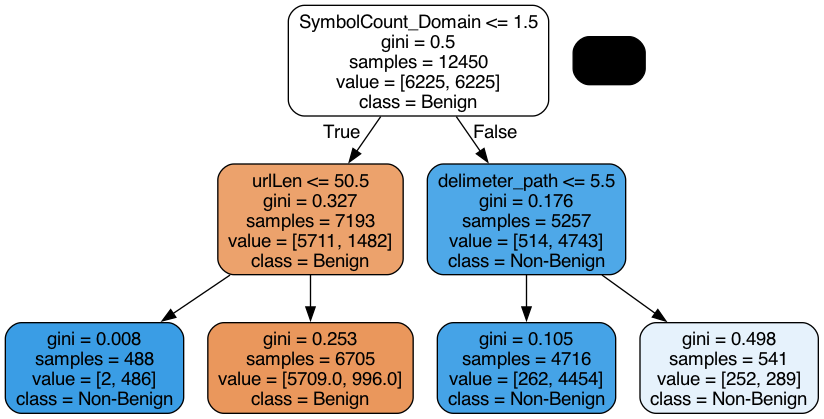

```python
from IPython.display import Image
Image(filename='tree.png')
```

The root node has a gini index of 0.5, which indicates maximum impurity—this means there’s an equal number of benign and malicious URLs at this level. This is expected because the training set was undersampled to balance the classes and improve accuracy. At the root, the tree uses SymbolCount_Domain, which represents the number of special characters in the URL. A higher count often indicates a suspicious or malicious URL, as attackers might use symbols to mimic real URLs (e.g., "F@ce_book.com"). The tree finds that URLs with 1.5 or fewer special characters form a good cutoff, splitting the data into two groups: 7,193 URLs on the left and 5,257 on the right. The left child node has a gini index of 0.327, which is an improvement but still shows some impurity. It then uses urlLen (URL length) as a splitting criterion. URLs shorter than 51 characters are classified as non-benign (malicious), with only 2 misclassified out of 488, resulting in a very low gini index of 0.008—indicating near-perfect classification. Longer URLs (51 characters or more) are mostly benign (85%), but 996 out of 6,705 are misclassified, leading to a gini of 0.253. Back at the first split, URLs with more than 1.5 special characters go to the right node, which uses delimeter_path (number of delimiters in the URL) as a criterion. This node already has a relatively low gini of 0.176, with a 514-4,743 split. If a URL has fewer than 6 delimiters, the gini drops further to 0.105, reducing misclassifications to 262. However, if a URL has 6 or more delimiters, the classification becomes uncertain again, with a nearly even split and a gini of 0.498. However, this leaf only has 541 instances out of the original 12,450.